# Raw Financial Data and Bankruptcy Prediction: An Application of Machine Learning

# 1 Analysis

## 1.1 Principal Component Analysis

We use principal component analysis here to understand which most explains bankruptcy in companies. This one of four tools that will be used in this analysis to measure the importance of features in bankruptcy prediction. The other features are: random forest future importance, Boosting feature importance, and the Logit regression feature importance.

Removing the Industry Variable

```r
y1.all <- y1.all %>% mutate(Industry = NULL)
```

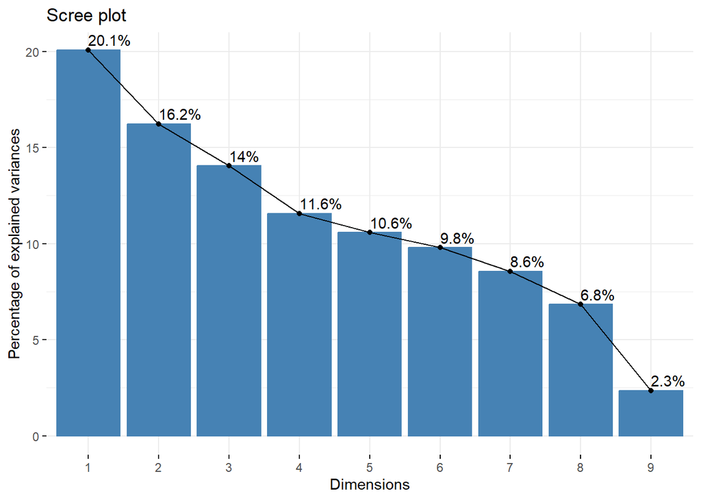

```r
independent_vars <- y1.all[,-c(1)]

independent_vars_scaled <- scale(independent_vars)

pca <- prcomp(independent_vars_scaled, center = TRUE, scale = TRUE)

fviz_eig(pca, addlabels = TRUE, ylim = c(0, 20))
```

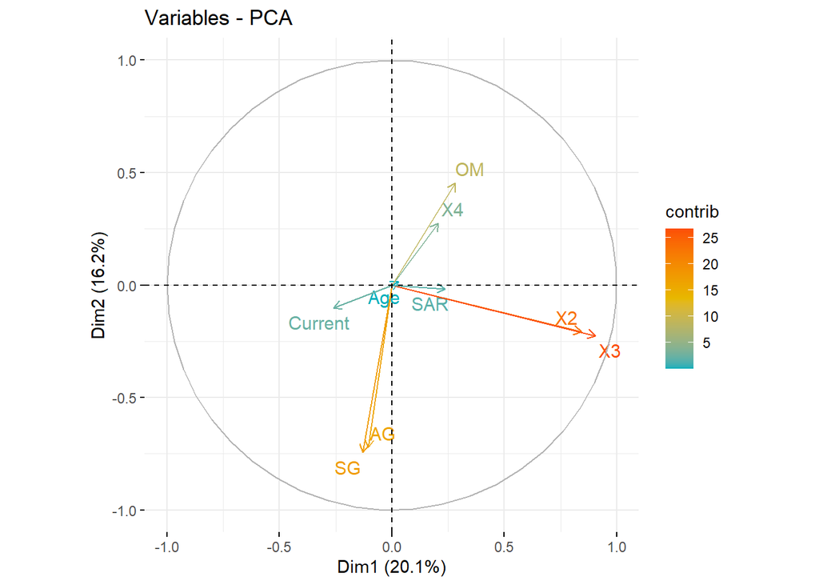

```r
fviz_pca_var(pca, col.var = "contrib", gradient.cols = c("#00AFBB", "#E7B800", "#FC4E07"), repel = TRUE)
```

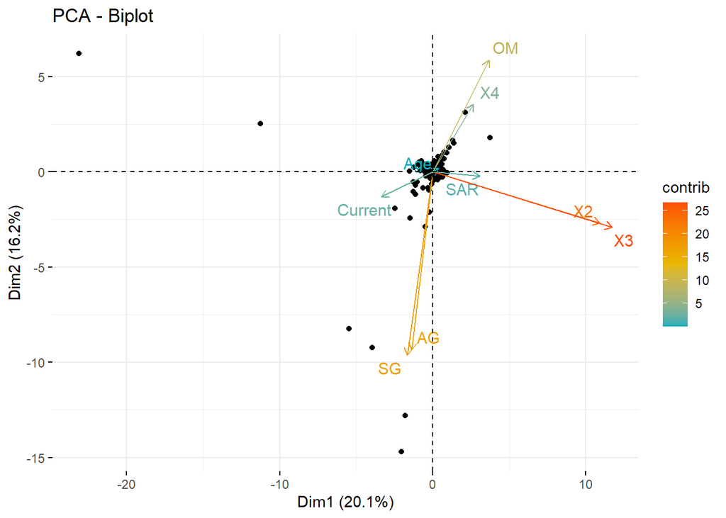

```r
fviz_pca_biplot(pca, label = "var", col.var = "contrib", gradient.cols = c("#00AFBB", "#E7B800", "#FC4E07"), repel = TRUE)
```

```r
loadings <- capture.output(pca$rotation)
kable(loadings, caption = "PCA Features")
```

PCA Features

| x |
| --- |
| PC1 PC2 PC3 PC4 PC5 PC6 |
| Age 0.02172828 0.01225854 0.64053080 0.3555182 0.21335999 -0.15553089 |
| X2 0.62765951 -0.17223142 0.10898481 -0.0416370 0.25689911 0.20993459 |
| X3 0.67396151 -0.18677662 -0.05999314 0.1109815 0.01694462 0.05183189 |
| X4 0.15327868 0.22710515 0.01988269 -0.8108939 -0.08186121 0.12889392 |
| OM 0.21045019 0.37484763 0.11165682 -0.1708831 0.14013493 -0.81955932 |
| AG -0.07906413 -0.59788692 0.15403902 -0.2368538 -0.16203609 -0.21067490 |
| SG -0.09610521 -0.61529462 -0.01706308 -0.1801324 0.02262717 -0.32080484 |
| Current -0.19258694 -0.08344092 -0.30757200 -0.1047602 0.89495664 0.02298445 |
| SAR 0.17603008 -0.01394428 -0.66540300 0.2707105 -0.18476771 -0.30484750 |
| PC7 PC8 PC9 |
| Age 0.54491339 0.29471630 0.095937977 |
| X2 -0.22258951 -0.09381018 0.627974864 |
| X3 0.09116886 0.02733236 -0.694940162 |
| X4 0.41209209 0.27023282 0.028705707 |
| OM -0.22676567 -0.17325716 -0.027851618 |
| AG 0.32184486 -0.61746042 0.031164851 |
| SG -0.28619181 0.62771758 0.008640256 |
| Current 0.16580050 -0.09306541 -0.112898117 |
| SAR 0.45933574 0.12885329 0.313225206 |

```r
#writeLines(loadings, "PCA_Features.txt")
```

It can be observed that the first two dimensions of the PCA capture 36% of the variance in the dataset. Net profit, revenue, ebitda, and equity and the top ranked features by the PCA.

# 2 Correlation Matrices

As noted by Wang, Ma, and Yang (2013) predictive models are not resistant to multicollinearity especially those that apply traditional statistical methods such as the EMS model and logistic regression. It is therefore essential to analyse the extent to which the variables used in the models vary together.

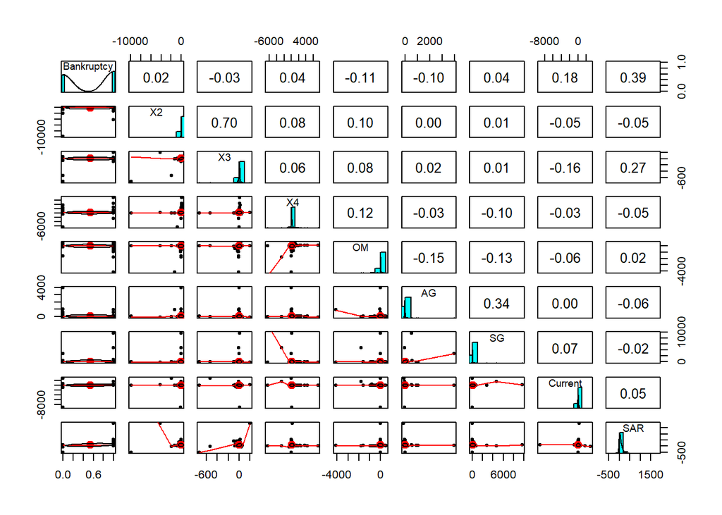

```r
y1.all[,-2]%>%pairs.panels()
```

```r
correlation.data <- print(cor(y1.all, use= "complete.obs"))
```

```
            Bankruptcy         Age           X2           X3          X4
Bankruptcy  1.00000000 -0.45143072  0.023041066 -0.025698194  0.03821941
Age        -0.45143072  1.00000000  0.020041407  0.041141104 -0.08589133
X2          0.02304107  0.02004141  1.000000000  0.702594529  0.07598785
X3         -0.02569819  0.04114110  0.702594529  1.000000000  0.06328110
X4          0.03821941 -0.08589133  0.075987850  0.063281095  1.00000000
OM         -0.11353552  0.05572959  0.095002434  0.075858953  0.12474752
AG         -0.10199850  0.04298929 -0.001855104  0.023114726 -0.02773071
SG          0.03558765 -0.05292596  0.011374963  0.006125439 -0.10353666
Current     0.17569052 -0.06788315 -0.050149280 -0.158408387 -0.03086085
SAR         0.39436522 -0.20513810 -0.046630937  0.271522792 -0.05239706
                    OM            AG           SG       Current         SAR
Bankruptcy -0.11353552 -0.1019984987  0.035587647  0.1756905175  0.39436522
Age         0.05572959  0.0429892925 -0.052925956 -0.0678831458 -0.20513810
X2          0.09500243 -0.0018551036  0.011374963 -0.0501492800 -0.04663094
X3          0.07585895  0.0231147259  0.006125439 -0.1584083872  0.27152279
X4          0.12474752 -0.0277307140 -0.103536660 -0.0308608514 -0.05239706
OM          1.00000000 -0.1533823092 -0.125805338 -0.0592621999  0.01689716
AG         -0.15338231  1.0000000000  0.338679309 -0.0002927153 -0.05724938
SG         -0.12580534  0.3386793087  1.000000000  0.0747657528 -0.02322587
Current    -0.05926220 -0.0002927153  0.074765753  1.0000000000  0.04992567
SAR         0.01689716 -0.0572493823 -0.023225865  0.0499256734  1.00000000
```

```r
symnum(correlation.data)
```

```
           B Ag X2 X3 X4 O AG SG C SA
Bankruptcy 1
Age        . 1
X2              1
X3              ,  1
X4                    1
OM                       1
AG                         1
SG                         .  1
Current                          1
SAR        .                       1
attr(,"legend")
[1] 0 ' ' 0.3 '.' 0.6 ',' 0.8 '+' 0.9 '*' 0.95 'B' 1
```

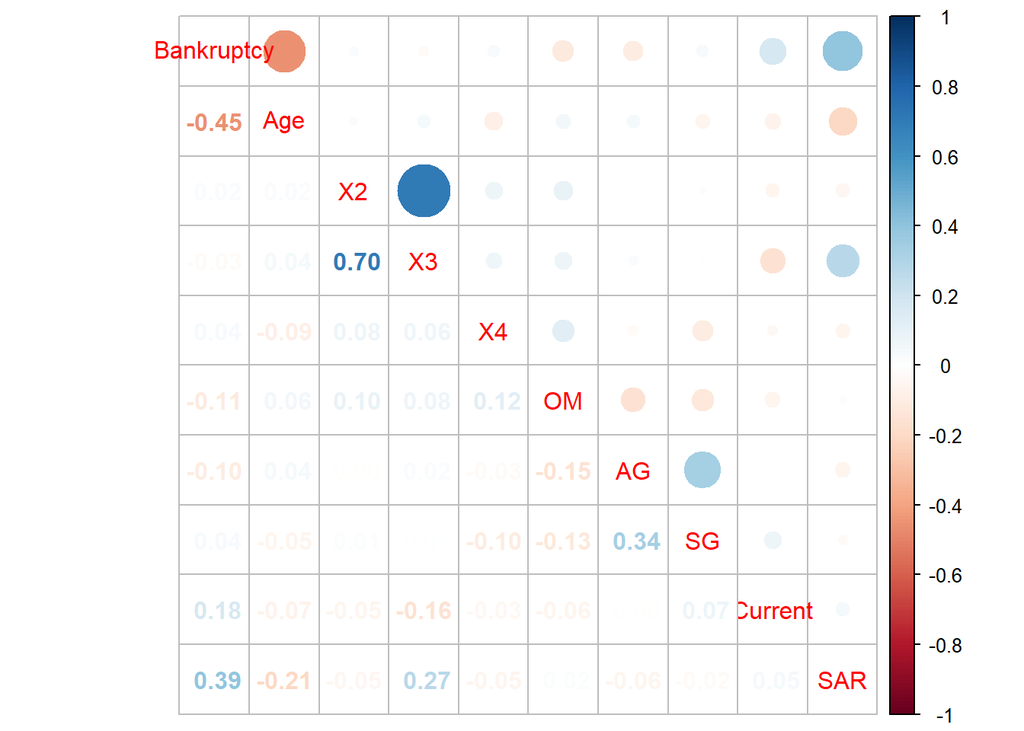

```r
corrplot(correlation.data, type="upper", tl.pos="d")
corrplot(correlation.data, add=TRUE, type="lower", method="number", diag=FALSE, tl.pos="n", cl.pos="n")
```

# 3 Statistical Testing

All features in the dataset were tested for their statistical significance at one year leading to bankruptcy. The spearman correlation rho estimate was used to test the explanatory variable for significance. Cassim (2020) observed that the method employed to test data for statistical significance should be based on the inherent characteristics of the data being tested. For example, when data is assumed to be parametric, i.e. normally distributed, then the commonly used procedures such as t-tests provide reliable results (Cassim, 2020).

## 3.1 Testing for Normality

```r
shapiro_results <- lapply(y1.all[,-1], shapiro.test)
shapiro.p_values <- sapply(shapiro_results, function(x) x$p.value)
shapiro.stat <- sapply(shapiro_results, function(x) x$statistic)

shapiro.data <- kable(cbind(shapiro.stat, shapiro.p_values), caption = "Shapiro-Test - H0: Data is normally distributed")

ad_results <- lapply(y1.all[,-1], ad.test)
ad.p_values <- sapply(ad_results, function(x) x$p.value)
ad.stat <- sapply(ad_results, function(x) x$statistic)

ad.data <- kable(cbind(ad.stat,ad.p_values), caption = "Anderson-Darling test - H0: Data is normally distributed")
```

## 3.2 Statistical Significance.

```r
set.seed(123)
train_index <- sample(1:nrow(y1.all), 0.7 * nrow(y1.all))
train_data <- y1.all[train_index, ]
test_data <- y1.all[-train_index, ]

logit_model <- glm(Bankruptcy ~ ., data = train_data, family = "binomial")
LM.sum <- summary(logit_model)
print(LM.sum)
```

```
Call:
glm(formula = Bankruptcy ~ ., family = "binomial", data = train_data)

Coefficients:
              Estimate Std. Error    z value Pr(>|z|)
(Intercept)  7.033e+14  8.927e+06   78782537   <2e-16 ***
Age         -4.470e+13  3.650e+05 -122452592   <2e-16 ***
X2           5.250e+11  1.085e+04   48399158   <2e-16 ***
X3           7.527e+12  1.450e+05   51919361   <2e-16 ***
X4           1.871e+11  5.437e+03   34404391   <2e-16 ***
OM          -7.358e+11  2.339e+04  -31462622   <2e-16 ***
AG          -3.356e+12  1.720e+04 -195091957   <2e-16 ***
SG           9.372e+11  6.804e+03  137736740   <2e-16 ***
Current      1.875e+12  2.214e+04   84704729   <2e-16 ***
SAR          7.427e+12  3.838e+04  193490638   <2e-16 ***
---
Signif. codes:  0 '***' 0.001 '**' 0.01 '*' 0.05 '.' 0.1 ' ' 1

(Dispersion parameter for binomial family taken to be 1)

    Null deviance:  428.71  on 309  degrees of freedom
Residual deviance: 5550.72  on 300  degrees of freedom
AIC: 5570.7

Number of Fisher Scoring iterations: 25
```

```r
cor_results <- mapply(function(x, y) cor.test(y, x, method = "spearman"), y1.all[,-1], y1.all[,1])
print(cor_results)
```

```
            Age                               X2
statistic   20706449                          15687829
parameter   NULL                              NULL
p.value     2.88663e-21                       0.08211625
estimate    -0.4290516                        -0.0826925
null.value  0                                 0
alternative "two.sided"                       "two.sided"
method      "Spearman's rank correlation rho" "Spearman's rank correlation rho"
data.name   "y and x"                         "y and x"
            X3                                X4
statistic   17912721                          14956189
parameter   NULL                              NULL
p.value     4.913496e-07                      0.4990655
estimate    -0.236243                         -0.03219851
null.value  0                                 0
alternative "two.sided"                       "two.sided"
method      "Spearman's rank correlation rho" "Spearman's rank correlation rho"
data.name   "y and x"                         "y and x"
            OM                                AG
statistic   18942682                          19493303
parameter   NULL                              NULL
p.value     3.821507e-11                      7.485864e-14
estimate    -0.3073255                        -0.3453266
null.value  0                                 0
alternative "two.sided"                       "two.sided"
method      "Spearman's rank correlation rho" "Spearman's rank correlation rho"
data.name   "y and x"                         "y and x"
            SG                                Current
statistic   17997359                          3143647
parameter   NULL                              NULL
p.value     2.498612e-07                      5.45904e-93
estimate    -0.2420843                        0.7830418
null.value  0                                 0
alternative "two.sided"                       "two.sided"
method      "Spearman's rank correlation rho" "Spearman's rank correlation rho"
data.name   "y and x"                         "y and x"
            SAR
statistic   6825554
parameter   NULL
p.value     2.664341e-33
estimate    0.5289357
null.value  0
alternative "two.sided"
method      "Spearman's rank correlation rho"
data.name   "y and x"
```

```r
lM.pvalues <- print(LM.sum$coefficients[,4])
```

```
(Intercept)         Age          X2          X3          X4          OM
          0           0           0           0           0           0
         AG          SG     Current         SAR
          0           0           0           0
```

```r
adjusted_p <- p.adjust(lM.pvalues, method = "fdr")
print(adjusted_p)
```

```
(Intercept)         Age          X2          X3          X4          OM
          0           0           0           0           0           0
         AG          SG     Current         SAR
          0           0           0           0
```

```r
summary(logit_model)
```

```
Call:
glm(formula = Bankruptcy ~ ., family = "binomial", data = train_data)

Coefficients:
              Estimate Std. Error    z value Pr(>|z|)
(Intercept)  7.033e+14  8.927e+06   78782537   <2e-16 ***
Age         -4.470e+13  3.650e+05 -122452592   <2e-16 ***
X2           5.250e+11  1.085e+04   48399158   <2e-16 ***
X3           7.527e+12  1.450e+05   51919361   <2e-16 ***
X4           1.871e+11  5.437e+03   34404391   <2e-16 ***
OM          -7.358e+11  2.339e+04  -31462622   <2e-16 ***
AG          -3.356e+12  1.720e+04 -195091957   <2e-16 ***
SG           9.372e+11  6.804e+03  137736740   <2e-16 ***
Current      1.875e+12  2.214e+04   84704729   <2e-16 ***
SAR          7.427e+12  3.838e+04  193490638   <2e-16 ***
---
Signif. codes:  0 '***' 0.001 '**' 0.01 '*' 0.05 '.' 0.1 ' ' 1

(Dispersion parameter for binomial family taken to be 1)

    Null deviance:  428.71  on 309  degrees of freedom
Residual deviance: 5550.72  on 300  degrees of freedom
AIC: 5570.7

Number of Fisher Scoring iterations: 25
```

# 4 Visualising Balance

**Data Balance Visualisation**  
A crucial aspect of any machine learning and modelling venture requires understanding the distribution of the dataset(s) to be used. Balance is defined as the degree to which the classes or labels are fairly represented. The balance of a dataset has a singular impact on the accuracy and reliability of a machine learning model. While ideally, a 50-50 split is recommended, most researchers struggle to get data. Thus, literature accepts up to 30-70 class split as balanced.

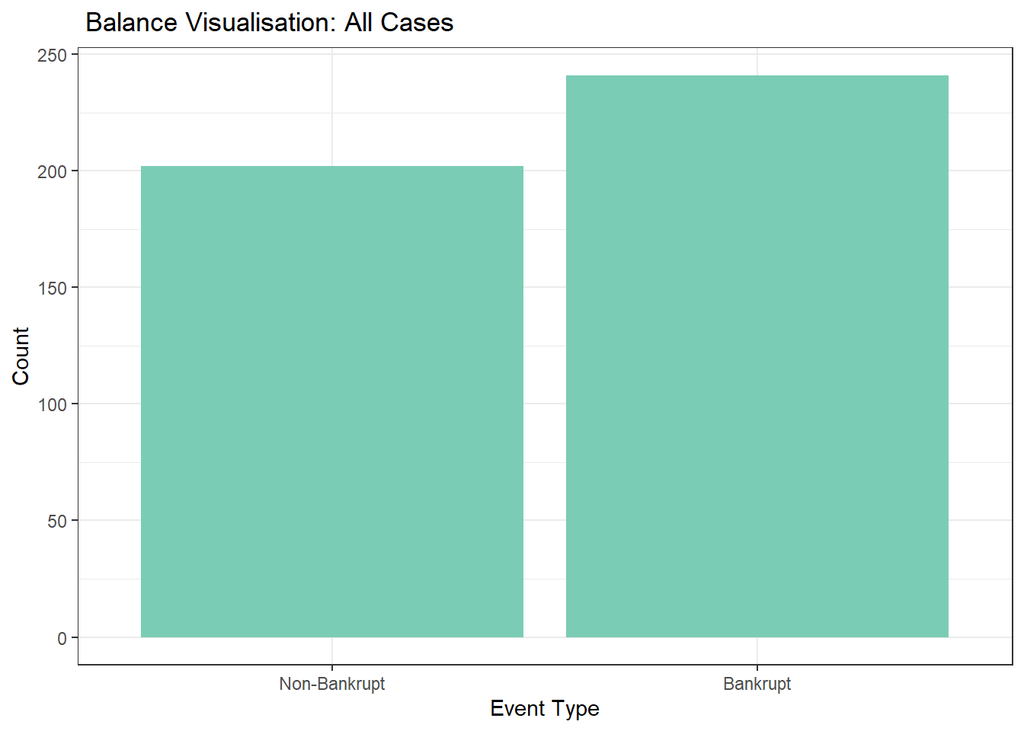

```r
ggplot(y1.all,aes(x=factor(y1.all$Bankruptcy, levels = c(0,1), labels = c("Non-Bankrupt", "Bankrupt"))))+
  geom_bar(fill = "#7BCCB5")+ ggtitle(" Balance Visualisation: All Cases")+
  ylab("Count") + xlab("Event Type") + scale_x_discrete(labels = c("Non-Bankrupt", "Bankrupt"))+
  theme_bw()
```

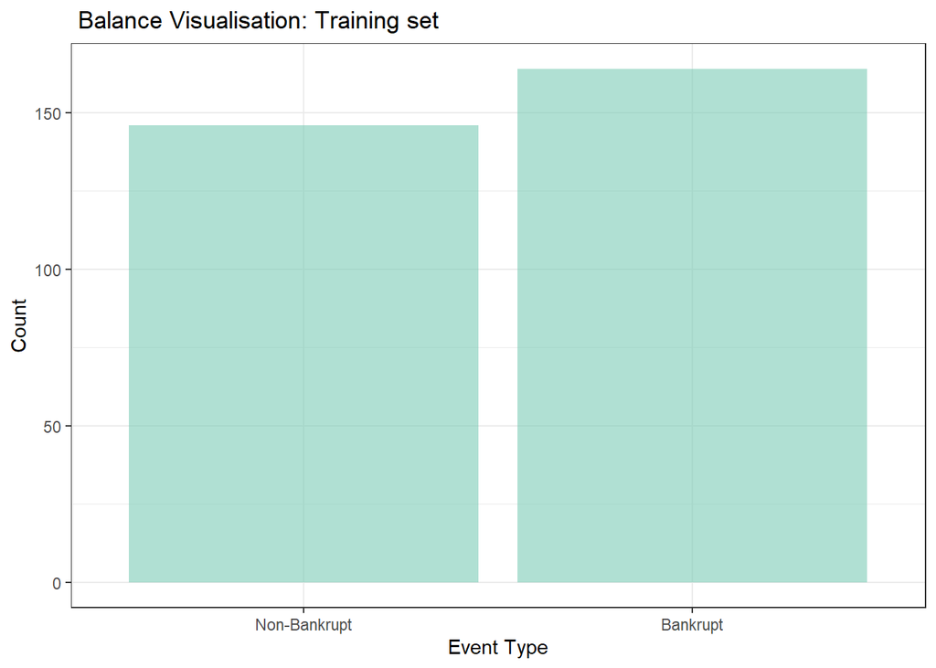

```r
ggplot(train_data,aes(x=factor(train_data$Bankruptcy, levels = c(0,1), labels = c("Non-Bankrupt", "Bankrupt"))))+
  geom_bar(fill = "#7BCCB5", alpha = 6/10)+ ggtitle(" Balance Visualisation: Training set")+
  ylab("Count") + xlab("Event Type") + scale_x_discrete(labels = c("Non-Bankrupt", "Bankrupt"))+
  theme_bw()
```

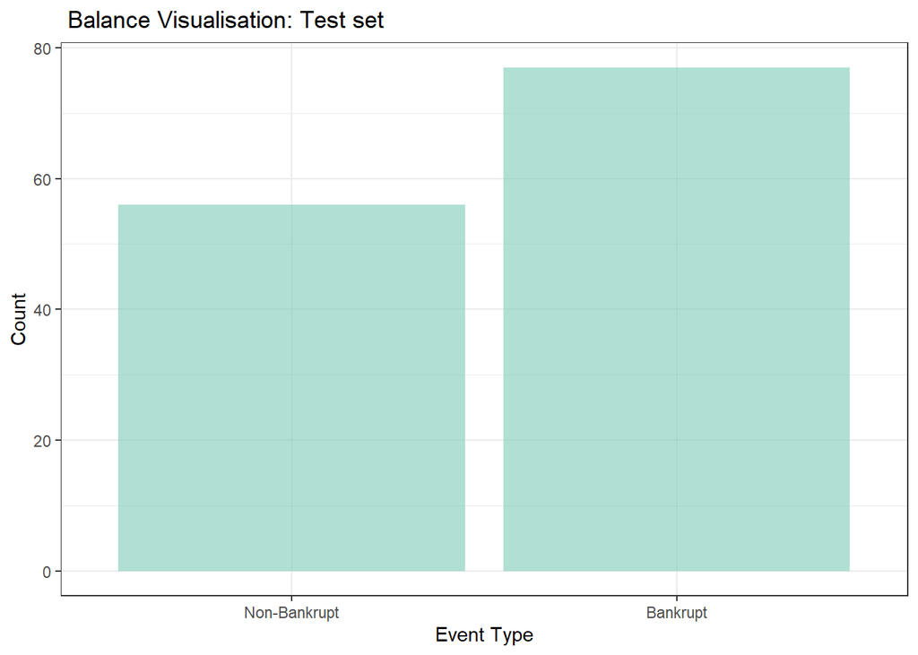

```r
ggplot(test_data,aes(x=factor(test_data$Bankruptcy, levels = c(0,1), labels = c("Non-Bankrupt", "Bankrupt"))))+
  geom_bar(fill = "#7BCCB5", alpha = 6/10)+ ggtitle(" Balance Visualisation: Test set")+
  ylab("Count") + xlab("Event Type") + scale_x_discrete(labels = c("Non-Bankrupt", "Bankrupt"))+
  theme_bw()
```

**Section 2: Models** 1. Random Forest

```r
# Split data into training and testing sets
set.seed(123) # for reproducibility
train_index <- sample(1:nrow(y1.all), 0.7 * nrow(y1.all))
train_data <- y1.all[train_index, ]
test_data <- y1.all[-train_index, ]

# Train random forest model
rf1 <- randomForest(Bankruptcy ~ ., data = train_data, ntree = 100, mtry = 3)
rf2 <- randomForest(Bankruptcy ~ ., data = train_data, ntree = 200, mtry = 1)

#OUT OF SAMPLE PERFORMANCE
RF_ensemble_pred <- (predict(rf1, test_data) + predict(rf2, test_data)) / 2

# Make predictions on test data
RF_ensemble_pred_binary <- ifelse(RF_ensemble_pred >= 0.5, 1, 0)

# Evaluate model performance (Confusion Matrix)
RF_cm <- table(RF_ensemble_pred_binary, test_data$Bankruptcy)
RF_accuracy.y1.all <- sum(diag(RF_cm)) / sum(RF_cm)

#Accuracy
RF_accuracy.y1.all
```

```
[1] 0.9473684
```

```r
y1.all.accuracy <- c()
y1.all.accuracy <- c(y1.all.accuracy, RF = RF_accuracy.y1.all)

###
RFa1.conf.m <- confusionMatrix(data = as.factor(RF_ensemble_pred_binary),reference = as.factor(test_data$Bankruptcy))

RFa1.pvalues <- RFa1.conf.m$overall[c("Accuracy","AccuracyPValue", "McnemarPValue")]

RFa1 <- RFa1.conf.m$byClass[c("Sensitivity","Specificity", "Prevalence", "Balanced Accuracy", "F1", "Precision")]

RFa1.errors <- c("Type 1 Error" = 1 - RFa1.conf.m$byClass["Specificity"], "Type II Error" = 1 - RFa1.conf.m$byClass["Sensitivity"])

RFa1.acc <- print(round(c(RFa1,
                          RFa1.pvalues,
                          RFa1.errors),3))
```

```
              Sensitivity               Specificity                Prevalence
                    0.946                     0.948                     0.421
        Balanced Accuracy                        F1                 Precision
                    0.947                     0.938                     0.930
                 Accuracy            AccuracyPValue             McnemarPValue
                    0.947                     0.000                     1.000
 Type 1 Error.Specificity Type II Error.Sensitivity
                    0.052                     0.054
```

```r
#IN-SAMPLE PERFORMANCE
RF_ensemble_pred.in.sample <- (predict(rf1, train_data) + predict(rf2, train_data)) / 2
# Make predictions on test data
RF_ensemble_pred_binary.in.sample <- ifelse(RF_ensemble_pred.in.sample >= 0.5, 1, 0)

# Evaluate model performance (Confusion Matrix)
RF_cm.in.sample <- table(RF_ensemble_pred_binary.in.sample, train_data$Bankruptcy)
RF_accuracy.y1.all.in.sample <- sum(diag(RF_cm.in.sample)) / sum(RF_cm.in.sample)

#Accuracy
RF_accuracy.y1.all.in.sample
```

```
[1] 0.9935484
```

```r
y1.all.accuracy.in.sample <- c()
y1.all.accuracy.in.sample <- c(y1.all.accuracy.in.sample, RF = RF_accuracy.y1.all.in.sample)

###
RFa1.conf.m.in.sample <- confusionMatrix(data = as.factor(RF_ensemble_pred_binary.in.sample),reference = as.factor(train_data$Bankruptcy))

RFa1.pvalues.in.sample <- RFa1.conf.m.in.sample$overall[c("Accuracy","AccuracyPValue", "McnemarPValue")]

RFa1.in.sample <- RFa1.conf.m.in.sample$byClass[c("Sensitivity","Specificity", "Prevalence", "Balanced Accuracy", "F1", "Precision")]

RFa1.errors.in.sample <- c("Type 1 Error" = 1 - RFa1.conf.m.in.sample$byClass["Specificity"], "Type II Error" = 1 - RFa1.conf.m.in.sample$byClass["Sensitivity"])

RFa1.acc.in.sample <- round(c(RFa1.in.sample,RFa1.pvalues.in.sample,RFa1.errors.in.sample), 3)
RFa1.acc.in.sample
```

```
              Sensitivity               Specificity                Prevalence
                    0.986                     1.000                     0.471
        Balanced Accuracy                        F1                 Precision
                    0.993                     0.993                     1.000
                 Accuracy            AccuracyPValue             McnemarPValue
                    0.994                     0.000                     0.480
 Type 1 Error.Specificity Type II Error.Sensitivity
                    0.000                     0.014
```

2. Boosting

Boosting involves training multiple models sequentially, and each subsequent model focuses on retraining on the instances that the previous models failed to learn and the results from each model are aggregated to form a final prediction (Hastie, Tibshirani & Friedman, 2009). Furthermore, like bagging, boosting can be used with a variety of different base models, including decision trees, linear regression, and logistic regression. Boosting can be used to improve the accuracy of a model, especially when there is high bias in the data. Bias is used in machine learning and statistics to mean the difference between the predicted and the actual value (Pawełek, 2019).

```r
# Train Boosting model
boost_model <- gbm(Bankruptcy ~ ., data = train_data, n.trees = 1000, interaction.depth = 10, shrinkage = 0.01, distribution = "bernoulli")

# Make predictions on test data
Boosting_predictions <- predict(boost_model, newdata = test_data, n.trees = 1000, type = "response")

# Convert predictions to binary classification
boosting_predictions_binary <- ifelse(Boosting_predictions > 0.5, 1, 0)

# Evaluate model performance
Boosting_confusion_matrix <- table(boosting_predictions_binary, test_data$Bankruptcy)
Boosting_accuracy.y1.all <- sum(diag(Boosting_confusion_matrix)) / sum(Boosting_confusion_matrix)

Boosting_accuracy.y1.all
```

```
[1] 0.9473684
```

```r
y1.all.accuracy <- c(y1.all.accuracy,Boost = Boosting_accuracy.y1.all)

###
Boostinga1.conf.m <- confusionMatrix(data = as.factor(boosting_predictions_binary),reference = as.factor(test_data$Bankruptcy))

Boostinga1.pvalues <- Boostinga1.conf.m$overall[c("Accuracy","AccuracyPValue", "McnemarPValue")]

Boostinga1 <- Boostinga1.conf.m$byClass[c("Sensitivity","Specificity", "Prevalence", "Balanced Accuracy", "F1", "Precision")]

Boostinga1.errors <- c("Type 1 Error" = 1 - Boostinga1.conf.m$byClass["Specificity"], "Type II Error" = 1 - Boostinga1.conf.m$byClass["Sensitivity"])

Boostinga1.acc <- print(round(c(Boostinga1,
                                Boostinga1.pvalues,
                                Boostinga1.errors),3))
```

```
              Sensitivity               Specificity                Prevalence
                    0.946                     0.948                     0.421
        Balanced Accuracy                        F1                 Precision
                    0.947                     0.938                     0.930
                 Accuracy            AccuracyPValue             McnemarPValue
                    0.947                     0.000                     1.000
 Type 1 Error.Specificity Type II Error.Sensitivity
                    0.052                     0.054
```

```r
### IN-SAMPLE PERFORMANCE
# Make predictions on test data
Boosting_predictions.in.sample <- predict(boost_model, newdata = train_data, n.trees = 1000, type = "response")

# Convert predictions to binary classification
boosting_predictions_binary.in.sample <- ifelse(Boosting_predictions.in.sample > 0.5, 1, 0)

# Evaluate model performance
Boosting_confusion_matrix.in.sample <- table(boosting_predictions_binary.in.sample, train_data$Bankruptcy)
Boosting_accuracy.y1.all.in.sample <- sum(diag(Boosting_confusion_matrix.in.sample)) / sum(Boosting_confusion_matrix.in.sample)

Boosting_accuracy.y1.all.in.sample
```

```
[1] 1
```

```r
y1.all.accuracy.in.sample <- c(y1.all.accuracy.in.sample,Boost = Boosting_accuracy.y1.all.in.sample)

###
Boostinga1.conf.m.in.sample <- confusionMatrix(data = as.factor(boosting_predictions_binary.in.sample),reference = as.factor(train_data$Bankruptcy))

Boostinga1.pvalues.in.sample <- Boostinga1.conf.m.in.sample$overall[c("Accuracy","AccuracyPValue", "McnemarPValue")]

Boostinga1.in.sample <- Boostinga1.conf.m.in.sample$byClass[c("Sensitivity","Specificity", "Prevalence", "Balanced Accuracy", "F1", "Precision")]

Boostinga1.errors.in.sample <- c("Type 1 Error" = 1 - Boostinga1.conf.m.in.sample$byClass["Specificity"], "Type II Error" = 1 - Boostinga1.conf.m.in.sample$byClass["Sensitivity"])

Boostinga1.acc.in.sample <-round( c(Boostinga1.in.sample,
                                    Boostinga1.pvalues.in.sample,
                                    Boostinga1.errors.in.sample), 3)
print(Boostinga1.acc.in.sample)
```

```
              Sensitivity               Specificity                Prevalence
                    1.000                     1.000                     0.471
        Balanced Accuracy                        F1                 Precision
                    1.000                     1.000                     1.000
                 Accuracy            AccuracyPValue             McnemarPValue
                    1.000                     0.000                       NaN
 Type 1 Error.Specificity Type II Error.Sensitivity
                    0.000                     0.000
```

3. Bagging

Bagging is an ensemble learning method that stands for bootstrap aggregating, and it involves creating multiple models on bootstrap samples of the data and combining their results to make a prediction (Hastie, Tibshirani &Friedman, 2009). Bagging can be used with a variety of different base models, including decision trees, linear regression, and logistic regression (Breimann, 1996). Bagging can improve the accuracy and robustness of a model, especially when there is high variance in the data (Breimann, 1996).

```r
# Train Bagging model
bag_model <- bagging(Bankruptcy ~ ., data = train_data, nbagg = 25)

#OUT-OF_SAMPLE
Bagging_predictions <- predict(bag_model, newdata = test_data)
Bagging_predictions_binary <- ifelse(Bagging_predictions >= 0.5, 1, 0)


# Evaluate model performance
Bagging_confusion_matrix <- table(Bagging_predictions_binary, test_data$Bankruptcy)
Bagging_accuracy.y1.all <- sum(diag(Bagging_confusion_matrix)) / sum(Bagging_confusion_matrix)

Bagging_accuracy.y1.all
```

```
[1] 0.9398496
```

```r
y1.all.accuracy <- c(y1.all.accuracy,Bag = Bagging_accuracy.y1.all)

###
Bagginga1.conf.m <- confusionMatrix(data = as.factor(Bagging_predictions_binary),reference = as.factor(test_data$Bankruptcy))

Bagginga1.pvalues <- Bagginga1.conf.m$overall[c("Accuracy","AccuracyPValue", "McnemarPValue")]

Bagginga1 <- Bagginga1.conf.m$byClass[c("Sensitivity","Specificity", "Prevalence", "Balanced Accuracy", "F1", "Precision")]

Bagginga1.errors <- c("Type 1 Error" = 1 - Bagginga1.conf.m$byClass["Specificity"], "Type II Error" = 1 - Bagginga1.conf.m$byClass["Sensitivity"])

Bagginga1.acc <- print(round(c(Bagginga1,
                               Bagginga1.pvalues,
                               Bagginga1.errors),3))
```

```
              Sensitivity               Specificity                Prevalence
                    0.946                     0.935                     0.421
        Balanced Accuracy                        F1                 Precision
                    0.941                     0.930                     0.914
                 Accuracy            AccuracyPValue             McnemarPValue
                    0.940                     0.000                     0.724
 Type 1 Error.Specificity Type II Error.Sensitivity
                    0.065                     0.054
```

```r
#IN-SAMPLE
Bagging_predictions.in.sample <- predict(bag_model, newdata = train_data)
Bagging_predictions_binary.in.sample <- ifelse(Bagging_predictions.in.sample >= 0.5, 1, 0)


# Evaluate model performance
Bagging_confusion_matrix.in.sample <- table(Bagging_predictions_binary.in.sample, train_data$Bankruptcy)
Bagging_accuracy.y1.all.in.sample <- sum(diag(Bagging_confusion_matrix.in.sample)) / sum(Bagging_confusion_matrix.in.sample)

Bagging_accuracy.y1.all.in.sample
```

```
[1] 0.9580645
```

```r
y1.all.accuracy.in.sample <- c(y1.all.accuracy.in.sample,Bag = Bagging_accuracy.y1.all.in.sample)

###
Bagginga1.conf.m.in.sample <- confusionMatrix(data = as.factor(Bagging_predictions_binary.in.sample),reference = as.factor(train_data$Bankruptcy))

Bagginga1.pvalues.in.sample <- Bagginga1.conf.m.in.sample$overall[c("Accuracy","AccuracyPValue", "McnemarPValue")]

Bagginga1.in.sample <- Bagginga1.conf.m.in.sample$byClass[c("Sensitivity","Specificity", "Prevalence", "Balanced Accuracy", "F1", "Precision")]

Bagginga1.errors.in.sample <- c("Type 1 Error" = 1 - Bagginga1.conf.m.in.sample$byClass["Specificity"], "Type II Error" = 1 - Bagginga1.conf.m.in.sample$byClass["Sensitivity"])

Bagginga1.acc.in.sample <-round(c(Bagginga1.in.sample,
                                  Bagginga1.pvalues.in.sample,
                                  Bagginga1.errors.in.sample),3)
print(Bagginga1.acc.in.sample)
```

```
              Sensitivity               Specificity                Prevalence
                    0.952                     0.963                     0.471
        Balanced Accuracy                        F1                 Precision
                    0.958                     0.955                     0.959
                 Accuracy            AccuracyPValue             McnemarPValue
                    0.958                     0.000                     1.000
 Type 1 Error.Specificity Type II Error.Sensitivity
                    0.037                     0.048
```

4. Support Vector Machines

Support Vector Machines, or SVMs, are a widely used machine learning model, particularly for classification tasks. SVMs work by finding the hyperplane that separates the data into different classes with the maximum margin (Hua et al., 2007). The main advantage of SVMs is their ability to handle high-dimensional datasets and produce accurate predictions (Pal et al., 2016; Hua et al., 2007; & Mitchell, 1997). They are also very good at handling datasets with complex boundaries between classes (Hua et al., 2007). Furthermore, SVMs are resistant to overfitting, which is a common problem in machine learning.

```r
# Normalize the data
normalized_data <- cbind(Bankruptcy = y1.all[,1], scale(y1.all[,-1]))
head(normalized_data,5)
```

```
  Bankruptcy        Age         X2          X3          X4         OM
1          1 -0.6994210 0.09237272  0.56959589 -0.26406457 0.10560913
2          1 -0.6072057 0.13041941  0.08470889  0.08981004 0.04193462
3          1 -0.6072057 0.09807973  0.08470889 -0.09439866 0.05387359
4          1 -0.6072057 0.09047039 -0.10502950 -0.20104581 0.01805668
5          1 -0.6072057 0.06954471 -0.06286542 -0.27860737 0.04591428
           AG          SG     Current        SAR
1 -0.22822049 -0.10203713  0.01489974  0.5148456
2 -0.10190412 -0.08887392  0.47598533  0.8137252
3  0.01955392 -0.08323255  0.23090380  0.1294482
4 -0.09704580 -0.08323255  0.24336558  0.3024838
5 -0.08247083 -0.08887392 -0.04325520 -0.5548288
```

```r
# Split data into training and testing sets
set.seed(123) # for reproducibility
n.train_index <- sample(1:nrow(normalized_data), 0.7 * nrow(normalized_data))
n.train_data <- normalized_data[n.train_index, ]
n.test_data <- normalized_data[-n.train_index, ]

#Train_model
svm_model <- svm(Bankruptcy ~ ., data = n.train_data, kernel = "radial", cost = 10 , gamma = 0.1)

#Tuned_Model
final_model <- best.tune(svm, Bankruptcy~., data = data.frame(n.train_data),
                 ranges = list(gamma = 2^(-1:1), cost = 2^(2:4)),
                  tunecontrol = tune.control(sampling = "fix"))

# Make predictions on test data
SVM_predictions <- predict(final_model, newdata=n.test_data)
SVM_predictions_binary <- ifelse(SVM_predictions>=0.5,1,0)

# Evaluate model performance
SVM_confusion_matrix <- table(SVM_predictions_binary, n.test_data[,"Bankruptcy"])
SVM_accuracy.y1.all <- sum(diag(SVM_confusion_matrix)) / sum(SVM_confusion_matrix)

SVM_accuracy.y1.all
```

```
[1] 0.9323308
```

```r
y1.all.accuracy <- c(y1.all.accuracy,SVM = SVM_accuracy.y1.all)

###
SVMa1.conf.m <- confusionMatrix(data = as.factor(SVM_predictions_binary),reference = as.factor(test_data$Bankruptcy))

SVMa1.pvalues <- SVMa1.conf.m$overall[c("Accuracy","AccuracyPValue", "McnemarPValue")]

SVMa1 <- SVMa1.conf.m$byClass[c("Sensitivity","Specificity", "Prevalence", "Balanced Accuracy", "F1", "Precision")]

SVMa1.errors <- c("Type 1 Error" = 1 - SVMa1.conf.m$byClass["Specificity"], "Type II Error" = 1 - SVMa1.conf.m$byClass["Sensitivity"])

SVMa1.acc <- print(round(c(SVMa1,
                           SVMa1.pvalues,
                           SVMa1.errors),3))
```

```
              Sensitivity               Specificity                Prevalence
                    0.946                     0.922                     0.421
        Balanced Accuracy                        F1                 Precision
                    0.934                     0.922                     0.898
                 Accuracy            AccuracyPValue             McnemarPValue
                    0.932                     0.000                     0.505
 Type 1 Error.Specificity Type II Error.Sensitivity
                    0.078                     0.054
```

```r
### IN OF SAMPLE

# Make predictions on test data
SVM_predictions.in.sample <- predict(final_model, newdata=n.train_data)
SVM_predictions_binary.in.sample <- ifelse(SVM_predictions.in.sample>=0.5,1,0)

# Evaluate model performance
SVM_confusion_matrix.in.sample <- table(SVM_predictions_binary.in.sample, n.train_data[,"Bankruptcy"])
SVM_accuracy.y1.all.in.sample <- sum(diag(SVM_confusion_matrix.in.sample)) / sum(SVM_confusion_matrix.in.sample)

SVM_accuracy.y1.all.in.sample
```

```
[1] 0.9645161
```

```r
y1.all.accuracy.in.sample <- c(y1.all.accuracy.in.sample,SVM = SVM_accuracy.y1.all.in.sample)

####
SVMa1.conf.m.in.sample <- confusionMatrix(data = as.factor(SVM_predictions_binary.in.sample),reference = as.factor(train_data$Bankruptcy))

SVMa1.pvalues.in.sample <- SVMa1.conf.m.in.sample$overall[c("Accuracy","AccuracyPValue", "McnemarPValue")]

SVMa1.in.sample <- SVMa1.conf.m.in.sample$byClass[c("Sensitivity","Specificity", "Prevalence", "Balanced Accuracy", "F1", "Precision")]

SVMa1.errors.in.sample <- c("Type 1 Error" = 1 - SVMa1.conf.m.in.sample$byClass["Specificity"], "Type II Error" = 1 - SVMa1.conf.m.in.sample$byClass["Sensitivity"])

SVMa1.acc.in.sample <- print(
  round(c(SVMa1.in.sample,
          SVMa1.pvalues.in.sample,
          SVMa1.errors.in.sample),3))
```

```
              Sensitivity               Specificity                Prevalence
                    0.973                     0.957                     0.471
        Balanced Accuracy                        F1                 Precision
                    0.965                     0.963                     0.953
                 Accuracy            AccuracyPValue             McnemarPValue
                    0.965                     0.000                     0.546
 Type 1 Error.Specificity Type II Error.Sensitivity
                    0.043                     0.027
```

5. Artificial Neural Networks

Artificial Neural Networks (ANN) is a machine learning model that is inspired by the structure of the human brain (James et al., 2013). ANN is highly versatile and can be used for a wide range of machine learning problems, including classification, regression, and unsupervised learning (James et al., 2013) ANN can also handle very large datasets with high-dimensional feature spaces.

```r
# Train ANN model
ann_model <- neuralnet(Bankruptcy ~ ., data = n.train_data, hidden = 10, threshold = 0.01)

# Make predictions on test data
ANN_predictions <- neuralnet::compute(ann_model, n.test_data[, -1])

# Convert predictions to binary classification
ANN_predictions_binary <- ifelse(ANN_predictions$net.result > 0.5, 1, 0)

# Evaluate model performance
ANN_confusion_matrix <- table(ANN_predictions_binary, n.test_data[, 1])
ANN_accuracy.y1.all <- sum(diag(ANN_confusion_matrix)) / sum(ANN_confusion_matrix)

ANN_accuracy.y1.all
```

```
[1] 0.9323308
```

```r
y1.all.accuracy <- c(y1.all.accuracy,ANN = ANN_accuracy.y1.all)

###
ANNa1.conf.m <- confusionMatrix(data = as.factor(ANN_predictions_binary),reference = as.factor(test_data$Bankruptcy))

ANNa1.pvalues <- ANNa1.conf.m$overall[c("Accuracy","AccuracyPValue", "McnemarPValue")]

ANNa1 <- ANNa1.conf.m$byClass[c("Sensitivity","Specificity", "Prevalence", "Balanced Accuracy", "F1", "Precision")]

ANNa1.errors <- c("Type 1 Error" = 1 - ANNa1.conf.m$byClass["Specificity"], "Type II Error" = 1 - ANNa1.conf.m$byClass["Sensitivity"])

ANNa1.acc <- print(round(c(ANNa1,
                           ANNa1.pvalues,
                           ANNa1.errors),3))
```

```
              Sensitivity               Specificity                Prevalence
                    0.911                     0.948                     0.421
        Balanced Accuracy                        F1                 Precision
                    0.929                     0.919                     0.927
                 Accuracy            AccuracyPValue             McnemarPValue
                    0.932                     0.000                     1.000
 Type 1 Error.Specificity Type II Error.Sensitivity
                    0.052                     0.089
```

```r
### IN SAMPLE PREDICTIONS
# Make predictions on test data
ANN_predictions.in.sample <- neuralnet::compute(ann_model, n.train_data[, -1])

# Convert predictions to binary classification
ANN_predictions_binary.in.sample <- ifelse(ANN_predictions.in.sample$net.result > 0.5, 1, 0)

# Evaluate model performance
ANN_confusion_matrix.in.sample <- table(ANN_predictions_binary.in.sample, n.train_data[, 1])
ANN_accuracy.y1.all.in.sample <- sum(diag(ANN_confusion_matrix.in.sample)) / sum(ANN_confusion_matrix.in.sample)

ANN_accuracy.y1.all
```

```
[1] 0.9323308
```

```r
y1.all.accuracy.in.sample <- c(y1.all.accuracy.in.sample,ANN = ANN_accuracy.y1.all.in.sample)

####
ANNa1.conf.m.in.sample <- confusionMatrix(data = as.factor(ANN_predictions_binary.in.sample),reference = as.factor(train_data$Bankruptcy))

ANNa1.pvalues.in.sample <- ANNa1.conf.m.in.sample$overall[c("Accuracy","AccuracyPValue", "McnemarPValue")]

ANNa1.in.sample <- ANNa1.conf.m.in.sample$byClass[c("Sensitivity","Specificity", "Prevalence", "Balanced Accuracy", "F1", "Precision")]

ANNa1.errors.in.sample <- c("Type 1 Error" = 1 - ANNa1.conf.m.in.sample$byClass["Specificity"], "Type II Error" = 1 - ANNa1.conf.m.in.sample$byClass["Sensitivity"])

ANNa1.acc.in.sample <- print(
  round(c(ANNa1.in.sample,
          ANNa1.pvalues.in.sample,
          ANNa1.errors.in.sample),3))
```

```
              Sensitivity               Specificity                Prevalence
                    0.979                     0.994                     0.471
        Balanced Accuracy                        F1                 Precision
                    0.987                     0.986                     0.993
                 Accuracy            AccuracyPValue             McnemarPValue
                    0.987                     0.000                     0.617
 Type 1 Error.Specificity Type II Error.Sensitivity
                    0.006                     0.021
```

6. k- Nearest Neighbours

KNN is a type of lazy learning algorithm, meaning that it does not learn a model from the training data, but rather it memorises all the training data points and uses them to make predictions (Alpaydin, 2010). The KNN algorithm works by finding the K-nearest neighbours to a given data point in the training set and using their labels to make a prediction for that data point (Alpaydin, 2010). The value of K refers to the number of neighbours that the model should look, and larger values of K tend to produce smoother decision boundaries, while smaller values of K can lead to overfitting.

```r
predictors<-c("Age", "X2", "X3", "X4", "OM", "AG", "SG", "Current", "SAR")

 response <- "Bankruptcy"


train = train_data[predictors]
cl = t(train_data[response])
test = test_data[predictors]

# Train kNN model
knn_model <- knn(train,
                 test,
                 cl,
                 k = 50,
                 prob = FALSE)

# Evaluate model performance
KNN_confusion_matrix <- table(knn_model, t(test_data[response]))
kNN_accuracy.y1.all <- sum(diag(KNN_confusion_matrix)) / sum(KNN_confusion_matrix)

kNN_accuracy.y1.all
```

```
[1] 0.9097744
```

```r
y1.all.accuracy <- c(y1.all.accuracy,kNN = kNN_accuracy.y1.all)

###
###
kNNa1.conf.m <- confusionMatrix(data = as.factor(knn_model),reference = as.factor(test_data$Bankruptcy))

kNNa1.pvalues <- kNNa1.conf.m$overall[c("Accuracy","AccuracyPValue", "McnemarPValue")]

kNNa1 <- kNNa1.conf.m$byClass[c("Sensitivity","Specificity", "Prevalence", "Balanced Accuracy", "F1", "Precision")]

kNNa1.errors <- c("Type 1 Error" = 1 - kNNa1.conf.m$byClass["Specificity"], "Type II Error" = 1 - kNNa1.conf.m$byClass["Sensitivity"])

kNNa1.acc <- print(round(c(kNNa1,
                           kNNa1.pvalues,
                           kNNa1.errors),3))
```

```
              Sensitivity               Specificity                Prevalence
                    0.982                     0.857                     0.421
        Balanced Accuracy                        F1                 Precision
                    0.920                     0.902                     0.833
                 Accuracy            AccuracyPValue             McnemarPValue
                    0.910                     0.000                     0.009
 Type 1 Error.Specificity Type II Error.Sensitivity
                    0.143                     0.018
```

```r
### IN SAMPLE PERFORMANCE
train = train_data[predictors]
cl = t(train_data[response])
test = train_data[predictors]

# Train kNN model
knn_model.in.sample <- knn(train,
                 test,
                 cl,
                 k = 50,
                 prob = FALSE)
KNN_confusion_matrix.in.sample <- table(knn_model.in.sample, t(train_data[response]))
kNN_accuracy.y1.all.in.sample <- sum(diag(KNN_confusion_matrix.in.sample)) / sum(KNN_confusion_matrix.in.sample)

kNN_accuracy.y1.all.in.sample
```

```
[1] 0.8419355
```

```r
y1.all.accuracy.in.sample <- c(y1.all.accuracy.in.sample,kNN = kNN_accuracy.y1.all.in.sample)

####
kNNa1.conf.m.in.sample <- confusionMatrix(data = as.factor(knn_model.in.sample),reference = as.factor(train_data$Bankruptcy))

kNNa1.pvalues.in.sample <- kNNa1.conf.m.in.sample$overall[c("Accuracy","AccuracyPValue", "McnemarPValue")]

kNNa1.in.sample <- kNNa1.conf.m.in.sample$byClass[c("Sensitivity","Specificity", "Prevalence", "Balanced Accuracy", "F1", "Precision")]

kNNa1.errors.in.sample <- c("Type 1 Error" = 1 - kNNa1.conf.m.in.sample$byClass["Specificity"], "Type II Error" = 1 - kNNa1.conf.m.in.sample$byClass["Sensitivity"])

kNNa1.acc.in.sample <- print(
  round(c(kNNa1.in.sample,
          kNNa1.pvalues.in.sample,
          kNNa1.errors.in.sample),3))
```

```
              Sensitivity               Specificity                Prevalence
                    0.904                     0.787                     0.471
        Balanced Accuracy                        F1                 Precision
                    0.845                     0.843                     0.790
                 Accuracy            AccuracyPValue             McnemarPValue
                    0.842                     0.000                     0.004
 Type 1 Error.Specificity Type II Error.Sensitivity
                    0.213                     0.096
```

7. Logistic Regression

Owing to its simplicity and interpretability, logistic regression is a choice algorithm for making binary predictions. As a linear model, logistic regression uses a sigmoid function to transform the output of a linear combination of input features into a probability of belonging to a particular class (Hastie, Tibshirani, & Friedman, 2009).

```r
# Train logistic regression model
logit_model <- glm(Bankruptcy ~ ., data = train_data, family = "binomial")

# Make predictions on test data
LR_probabilities <- predict(logit_model, newdata = test_data, type = "response")

# Convert predictions to binary classification
LR_predictions_binary <- ifelse(LR_probabilities > 0.5, 1, 0)

# Evaluate model performance
LR_confusion_matrix <- table(LR_predictions_binary, test_data$Bankruptcy)
LR_accuracy.y1.all <- sum(diag(LR_confusion_matrix)) / sum(LR_confusion_matrix)
LR_accuracy.y1.all
```

```
[1] 0.7969925
```

```r
y1.all.accuracy <- c(y1.all.accuracy,LR = LR_accuracy.y1.all)

###
LRa1.conf.m <- confusionMatrix(data = as.factor(LR_predictions_binary),reference = as.factor(test_data$Bankruptcy))

LRa1.pvalues <- LRa1.conf.m$overall[c("Accuracy","AccuracyPValue", "McnemarPValue")]

LRa1 <- LRa1.conf.m$byClass[c("Sensitivity","Specificity", "Prevalence", "Balanced Accuracy", "F1", "Precision")]

LRa1.errors <- c("Type 1 Error" = 1 - LRa1.conf.m$byClass["Specificity"], "Type II Error" = 1 - LRa1.conf.m$byClass["Sensitivity"])

LRa1.acc <- print(round(c(LRa1,
                          LRa1.pvalues,
                          LRa1.errors),3))
```

```
              Sensitivity               Specificity                Prevalence
                    0.643                     0.909                     0.421
        Balanced Accuracy                        F1                 Precision
                    0.776                     0.727                     0.837
                 Accuracy            AccuracyPValue             McnemarPValue
                    0.797                     0.000                     0.021
 Type 1 Error.Specificity Type II Error.Sensitivity
                    0.091                     0.357
```

```r
#### IN SAMPLE
# Make predictions on test data
LR_probabilities.in.sample <- predict(logit_model, newdata = train_data, type = "response")

# Convert predictions to binary classification
LR_predictions_binary.in.sample <- ifelse(LR_probabilities.in.sample > 0.5, 1, 0)

# Evaluate model performance
LR_confusion_matrix.in.sample <- table(LR_predictions_binary.in.sample, train_data$Bankruptcy)
LR_accuracy.y1.all.in.sample <- sum(diag(LR_confusion_matrix.in.sample)) / sum(LR_confusion_matrix.in.sample)
LR_accuracy.y1.all.in.sample
```

```
[1] 0.7516129
```

```r
y1.all.accuracy.in.sample <- c(y1.all.accuracy.in.sample,LR = LR_accuracy.y1.all.in.sample)

####
LRa1.conf.m.in.sample <- confusionMatrix(data = as.factor(LR_predictions_binary.in.sample),reference = as.factor(train_data$Bankruptcy))

LRa1.pvalues.in.sample <- LRa1.conf.m.in.sample$overall[c("Accuracy","AccuracyPValue", "McnemarPValue")]

LRa1.in.sample <- LRa1.conf.m.in.sample$byClass[c("Sensitivity","Specificity", "Prevalence", "Balanced Accuracy", "F1", "Precision")]

LRa1.errors.in.sample <- c("Type 1 Error" = 1 - LRa1.conf.m.in.sample$byClass["Specificity"], "Type II Error" = 1 - LRa1.conf.m.in.sample$byClass["Sensitivity"])

LRa1.acc.in.sample <- print(round(c(LRa1.in.sample,
                                    LRa1.pvalues.in.sample,
                                    LRa1.errors.in.sample),3))
```

```
              Sensitivity               Specificity                Prevalence
                    0.514                     0.963                     0.471
        Balanced Accuracy                        F1                 Precision
                    0.739                     0.661                     0.926
                 Accuracy            AccuracyPValue             McnemarPValue
                    0.752                     0.000                     0.000
 Type 1 Error.Specificity Type II Error.Sensitivity
                    0.037                     0.486
```